# IE48BFinal_seyma_cakir

seyma cakir

1/10/2022

#IE48B Final

set directory and set seed to prevent randomness each calculation.

```r
setwd('D:\\Users\\seyma\\Documents\\GitHub\\fall21-seymacakir\\IE48BFinal_seyma_cakir')
set.seed(448)
```

There is data is readed and shown for understand structure of data.

```r
raw_data = fread("production_with_weather_data.csv")
tail(raw_data)
```

```
##          date hour production DSWRF_surface_38_35 DSWRF_surface_38_35.25 DSWRF_surface_38_35.5
## 1: 2021-12-25   18          0              133.38                 131.64                126.48
## 2: 2021-12-25   19          0              100.04                  98.74                 94.84
## 3: 2021-12-25   20          0               80.02                  78.98                 75.88
## 4: 2021-12-25   21          0               66.68                  65.82                 63.24
## 5: 2021-12-25   22          0                0.00                   0.00                  0.00
##    DSWRF_surface_38_35.75 DSWRF_surface_38_36 DSWRF_surface_38.25_35 DSWRF_surface_38.25_35.25
## 1:                 123.18              118.72                 126.88                    122.24
## 2:                  92.38               89.04                  95.16                     91.68
## 3:                  73.90               71.24                  76.12                     73.34
## 4:                  61.60               59.36                  63.44                     61.12
## 5:                   0.00                0.00                   0.00                      0.00
##    DSWRF_surface_38.25_35.5 DSWRF_surface_38.25_35.75 DSWRF_surface_38.25_36 DSWRF_surface_38.5_35
## 1:                   121.88                    120.78                 119.36                125.58
## 2:                    91.42                     90.60                  89.52                 94.18
```

[output cut: 346 more lines]

```r
str(raw_data)
```

```
## Classes 'data.table' and 'data.frame':   20280 obs. of  178 variables:
##  $ date                               : IDate, format: "2019-09-01" "2019-09-01" "2019-09-01" ...
##  $ hour                               : int  0 1 2 3 4 5 6 7 8 9 ...
##  $ production                         : num  0 0 0 0 0 ...
##  $ DSWRF_surface_38_35                : num  0 0 0 0 0 0 0 9 51 115 ...
##  $ DSWRF_surface_38_35.25             : num  0 0 0 0 0 0 0 9 52 117 ...
##  $ DSWRF_surface_38_35.5              : num  0 0 0 0 0 0 0 9 51 114 ...
##  $ DSWRF_surface_38_35.75             : num  0 0 0 0 0 0 0 10 52 115 ...
##  $ DSWRF_surface_38_36                : num  0 0 0 0 0 0 0 10 51 114 ...
##  $ DSWRF_surface_38.25_35             : num  0 0 0 0 0 0 0 9 50 112 ...
##  $ DSWRF_surface_38.25_35.25          : num  0 0 0 0 0 0 0 9 50 112 ...
##  $ DSWRF_surface_38.25_35.5           : num  0 0 0 0 0 0 0 9 51 114 ...
##  $ DSWRF_surface_38.25_35.75          : num  0 0 0 0 0 0 0 10 51 115 ...
##  $ DSWRF_surface_38.25_36             : num  0 0 0 0 0 0 0 10 52 115 ...
##  $ DSWRF_surface_38.5_35              : num  0 0 0 0 0 0 0 9 50 113 ...
```

[output cut: 87 more lines]

```r
summary(raw_data)
```

```
##       date                 hour         production       DSWRF_surface_38_35 DSWRF_surface_38_35.25
##  Min.   :2019-09-01   Min.   : 0.00   Min.   :  0.0000   Min.   :  0.0       Min.   :  0.00
##  1st Qu.:2020-03-30   1st Qu.: 5.75   1st Qu.:  0.0004   1st Qu.:  0.0       1st Qu.:  0.00
##  Median :2020-10-27   Median :11.50   Median :  1.4348   Median : 76.0       Median : 74.21
##  Mean   :2020-10-27   Mean   :11.50   Mean   : 67.5243   Mean   :222.6       Mean   :221.17
##  3rd Qu.:2021-05-26   3rd Qu.:17.25   3rd Qu.:128.0000   3rd Qu.:410.0       3rd Qu.:403.80
##  DSWRF_surface_38_35.5 DSWRF_surface_38_35.75 DSWRF_surface_38_36 DSWRF_surface_38.25_35
##  Min.   :  0.00        Min.   :  0.0          Min.   :  0.00      Min.   :  0.0
##  1st Qu.:  0.00        1st Qu.:  0.0          1st Qu.:  0.00      1st Qu.:  0.0
##  Median : 64.25        Median : 60.0          Median : 59.65      Median : 71.0
##  Mean   :217.09        Mean   :214.6          Mean   :214.18      Mean   :220.1
##  3rd Qu.:396.16        3rd Qu.:390.0          3rd Qu.:391.54      3rd Qu.:400.0
##  DSWRF_surface_38.25_35.25 DSWRF_surface_38.25_35.5 DSWRF_surface_38.25_35.75 DSWRF_surface_38.25_36
##  Min.   :  0.0             Min.   :  0.0            Min.   :  0.0             Min.   :  0.00
##  1st Qu.:  0.0             1st Qu.:  0.0            1st Qu.:  0.0             1st Qu.:  0.00
##  Median : 70.0             Median : 70.0            Median : 70.0             Median : 65.96
##  Mean   :219.1             Mean   :218.5            Mean   :218.4             Mean   :217.68
##  3rd Qu.:400.0             3rd Qu.:400.0            3rd Qu.:400.0             3rd Qu.:399.52
##  DSWRF_surface_38.5_35 DSWRF_surface_38.5_35.25 DSWRF_surface_38.5_35.5 DSWRF_surface_38.5_35.75
##  Min.   :  0.0         Min.   :  0.00           Min.   :  0.0           Min.   :  0.0
##  1st Qu.:  0.0         1st Qu.:  0.00           1st Qu.:  0.0           1st Qu.:  0.0
##  Median : 70.0         Median : 70.04           Median : 70.0           Median : 70.0
##  Mean   :217.8         Mean   :220.49           Mean   :216.8           Mean   :217.6
##  3rd Qu.:400.0         3rd Qu.:400.00           3rd Qu.:399.7           3rd Qu.:400.0
##  DSWRF_surface_38.5_36 DSWRF_surface_38.75_35 DSWRF_surface_38.75_35.25 DSWRF_surface_38.75_35.5
##  Min.   :  0.0         Min.   :  0.0          Min.   :  0.00            Min.   :  0.0
##  1st Qu.:  0.0         1st Qu.:  0.0          1st Qu.:  0.00            1st Qu.:  0.0
##  Median : 70.0         Median : 70.0          Median : 68.71            Median : 66.4
##  Mean   :217.7         Mean   :215.5          Mean   :214.18            Mean   :212.5
##  3rd Qu.:400.0         3rd Qu.:390.0          3rd Qu.:390.00            3rd Qu.:388.3
##  DSWRF_surface_38.75_35.75 DSWRF_surface_38.75_36 DSWRF_surface_39_35 DSWRF_surface_39_35.25
##  Min.   :  0               Min.   :  0.0          Min.   :  0.00      Min.   :  0.00
##  1st Qu.:  0               1st Qu.:  0.0          1st Qu.:  0.00      1st Qu.:  0.00
##  Median : 70               Median : 70.0          Median : 69.99      Median : 68.56
##  Mean   :216               Mean   :217.9          Mean   :214.65      Mean   :213.79
##  3rd Qu.:392               3rd Qu.:400.0          3rd Qu.:390.00      3rd Qu.:390.00
##  DSWRF_surface_39_35.5 DSWRF_surface_39_35.75 DSWRF_surface_39_36 RH_2.m.above.ground_38_35
##  Min.   :  0.00        Min.   :  0.00         Min.   :  0.0       Min.   :  8.90
##  1st Qu.:  0.00        1st Qu.:  0.00         1st Qu.:  0.0       1st Qu.: 39.90
##  Median : 67.69        Median : 66.96         Median : 68.0       Median : 56.80
```

[output cut: 300 more lines]

```
##  Mean   :282.8                    Mean   :282.1                 Mean   :284.6
##  3rd Qu.:289.4                    3rd Qu.:288.9                 3rd Qu.:290.9
##  TMP_2.m.above.ground_39_35.25 TMP_2.m.above.ground_39_35.5 TMP_2.m.above.ground_39_35.75
##  Min.   :255.3                 Min.   :255.4                Min.   :254.7
##  1st Qu.:277.4                 1st Qu.:276.9                1st Qu.:276.4
##  Median :284.4                 Median :284.1                Median :284.0
##  Mean   :284.4                 Mean   :284.0                Mean   :283.7
##  3rd Qu.:290.6                 3rd Qu.:290.3                3rd Qu.:290.2
##  TMP_2.m.above.ground_39_36
##  Min.   :255.0
##  1st Qu.:276.3
##  Median :284.0
##  Mean   :283.6
##  3rd Qu.:290.2
##  [ reached getOption("max.print") -- omitted 2 rows ]
```

```r
data = raw_data[date < "2021-11-01" ]
tail(raw_data)
```

```
##          date hour production DSWRF_surface_38_35 DSWRF_surface_38_35.25 DSWRF_surface_38_35.5
## 1: 2021-12-25   18          0              133.38                 131.64                126.48
## 2: 2021-12-25   19          0              100.04                  98.74                 94.84
## 3: 2021-12-25   20          0               80.02                  78.98                 75.88
## 4: 2021-12-25   21          0               66.68                  65.82                 63.24
## 5: 2021-12-25   22          0                0.00                   0.00                  0.00
##    DSWRF_surface_38_35.75 DSWRF_surface_38_36 DSWRF_surface_38.25_35 DSWRF_surface_38.25_35.25
## 1:                 123.18              118.72                 126.88                    122.24
## 2:                  92.38               89.04                  95.16                     91.68
## 3:                  73.90               71.24                  76.12                     73.34
## 4:                  61.60               59.36                  63.44                     61.12
## 5:                   0.00                0.00                   0.00                      0.00
##    DSWRF_surface_38.25_35.5 DSWRF_surface_38.25_35.75 DSWRF_surface_38.25_36 DSWRF_surface_38.5_35
## 1:                   121.88                    120.78                 119.36                125.58
## 2:                    91.42                     90.60                  89.52                 94.18
```

[output cut: 346 more lines]

```r
test_data = raw_data[date >= "2021-11-01" ]
head(test_data)
```

```
##          date hour production DSWRF_surface_38_35 DSWRF_surface_38_35.25 DSWRF_surface_38_35.5
## 1: 2021-11-01    0     0.0000                   0                      0                     0
## 2: 2021-11-01    1     0.0000                   0                      0                     0
## 3: 2021-11-01    2     0.0002                   0                      0                     0
## 4: 2021-11-01    3     0.0001                   0                      0                     0
## 5: 2021-11-01    4     0.0157                   0                      0                     0
##    DSWRF_surface_38_35.75 DSWRF_surface_38_36 DSWRF_surface_38.25_35 DSWRF_surface_38.25_35.25
## 1:                      0                   0                      0                         0
## 2:                      0                   0                      0                         0
## 3:                      0                   0                      0                         0
## 4:                      0                   0                      0                         0
## 5:                      0                   0                      0                         0
##    DSWRF_surface_38.25_35.5 DSWRF_surface_38.25_35.75 DSWRF_surface_38.25_36 DSWRF_surface_38.5_35
## 1:                        0                         0                      0                     0
## 2:                        0                         0                      0                     0
```

[output cut: 346 more lines]

The graph of production during time is shown the graph in the below.

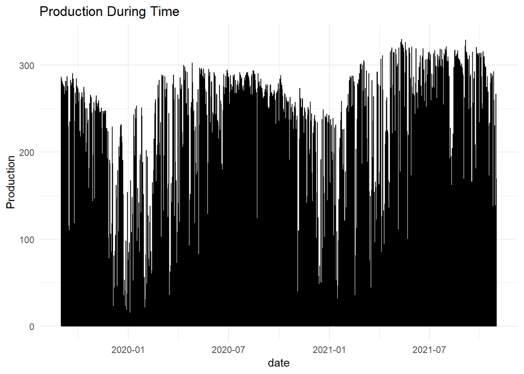

```r
ggplot(data, aes(x= date, y=production)) + geom_line() + labs( title = "Production During Time", xlab = "time", y= "Production") + theme_minimal()
```

## Summary

The production rate is modelled as basic time series linear regression model and than there are models which based on regresoors in the data based on residuals of regression models. Residual models are rpart models which aims to find the path of regressors values gives biggest absolute residuals. And path is added as regressors also.

## Methods

### LM base model

In the first the data is modeled as time series linear regression inculing seasonality based on month, day,and hour and trend variables. The summary of model is shown.

```r
data[,w_day:=as.character(wday(date,label=T))]
data[,mon:=as.character(month(date,label=T))]
data[,trnd:= 1:.N]

head(data[,c("date","hour","w_day","mon","hour","trnd","production")])
```

```
##          date hour w_day mon hour trnd production
## 1: 2019-09-01    0   Sun Sep    0    1     0.0000
## 2: 2019-09-01    1   Sun Sep    1    2     0.0000
## 3: 2019-09-01    2   Sun Sep    2    3     0.0000
## 4: 2019-09-01    3   Sun Sep    3    4     0.0000
## 5: 2019-09-01    4   Sun Sep    4    5     0.0000
## 6: 2019-09-01    5   Sun Sep    5    6     0.1912
```

```r
lm_base=lm(production~trnd+w_day+mon+as.factor(hour),data)
summary(lm_base)
```

```
##
## Call:
## lm(formula = production ~ trnd + w_day + mon + as.factor(hour),
##     data = data)
##
## Residuals:
##      Min       1Q   Median       3Q      Max
## -202.725  -18.792    1.477   27.842  106.046
##
## Coefficients:
##                     Estimate Std. Error t value Pr(>|t|)
## (Intercept)       -8.132e+00  1.961e+00  -4.147 3.39e-05 ***
## trnd               5.781e-04  5.620e-05  10.287  < 2e-16 ***
## w_dayMon           2.771e+00  1.085e+00   2.553   0.0107 *
## w_daySat           1.847e+00  1.085e+00   1.703   0.0886 .
## w_daySun           5.199e+00  1.083e+00   4.802 1.58e-06 ***
## w_dayThu           2.182e+00  1.087e+00   2.007   0.0448 *
## w_dayTue           4.272e+00  1.086e+00   3.936 8.33e-05 ***
## w_dayWed           2.285e+00  1.085e+00   2.106   0.0352 *
## monAug             1.962e+01  1.486e+00  13.203  < 2e-16 ***
## monDec            -3.452e+01  1.486e+00 -23.234  < 2e-16 ***
## monFeb            -1.427e+01  1.511e+00  -9.444  < 2e-16 ***
## monJan            -3.243e+01  1.481e+00 -21.894  < 2e-16 ***
## monJul             2.777e+01  1.482e+00  18.747  < 2e-16 ***
## monJun             2.069e+01  1.491e+00  13.877  < 2e-16 ***
## monMar            -1.138e+01  1.478e+00  -7.702 1.41e-14 ***
## monMay             1.731e+01  1.478e+00  11.714  < 2e-16 ***
## monNov            -1.288e+01  1.503e+00  -8.570  < 2e-16 ***
## monOct             1.773e+00  1.353e+00   1.310   0.1901
## monSep             1.144e+01  1.360e+00   8.413  < 2e-16 ***
## as.factor(hour)1  -1.782e-03  2.008e+00  -0.001   0.9993
## as.factor(hour)2  -2.374e-03  2.008e+00  -0.001   0.9991
## as.factor(hour)3  -1.400e-04  2.008e+00   0.000   0.9999
## as.factor(hour)4   1.611e-02  2.008e+00   0.008   0.9936
## as.factor(hour)5   6.283e-01  2.008e+00   0.313   0.7544
## as.factor(hour)6   7.992e+00  2.008e+00   3.980 6.92e-05 ***
## as.factor(hour)7   4.032e+01  2.008e+00  20.077  < 2e-16 ***
## as.factor(hour)8   9.761e+01  2.008e+00  48.605  < 2e-16 ***
## as.factor(hour)9   1.557e+02  2.008e+00  77.551  < 2e-16 ***
## as.factor(hour)10  1.985e+02  2.008e+00  98.856  < 2e-16 ***
## as.factor(hour)11  2.209e+02  2.008e+00 109.990  < 2e-16 ***
## as.factor(hour)12  2.261e+02  2.008e+00 112.595  < 2e-16 ***
## as.factor(hour)13  2.162e+02  2.008e+00 107.645  < 2e-16 ***
## as.factor(hour)14  1.919e+02  2.008e+00  95.568  < 2e-16 ***
## as.factor(hour)15  1.500e+02  2.008e+00  74.697  < 2e-16 ***
## as.factor(hour)16  9.594e+01  2.008e+00  47.774  < 2e-16 ***
## as.factor(hour)17  4.290e+01  2.008e+00  21.363  < 2e-16 ***
## as.factor(hour)18  1.062e+01  2.008e+00   5.288 1.25e-07 ***
## as.factor(hour)19  1.080e+00  2.008e+00   0.538   0.5906
## as.factor(hour)20  3.718e-03  2.008e+00   0.002   0.9985
## as.factor(hour)21 -5.124e-03  2.008e+00  -0.003   0.9980
## as.factor(hour)22 -1.742e-02  2.008e+00  -0.009   0.9931
## as.factor(hour)23 -1.722e-02  2.008e+00  -0.009   0.9932
## ---
## Signif. codes:  0 '***' 0.001 '**' 0.01 '*' 0.05 '.' 0.1 ' ' 1
##
## Residual standard error: 39.94 on 18942 degrees of freedom
## Multiple R-squared:  0.831,  Adjusted R-squared:  0.8307
## F-statistic:  2272 on 41 and 18942 DF,  p-value: < 2.2e-16
```

the prediction values and actual values plotted below.

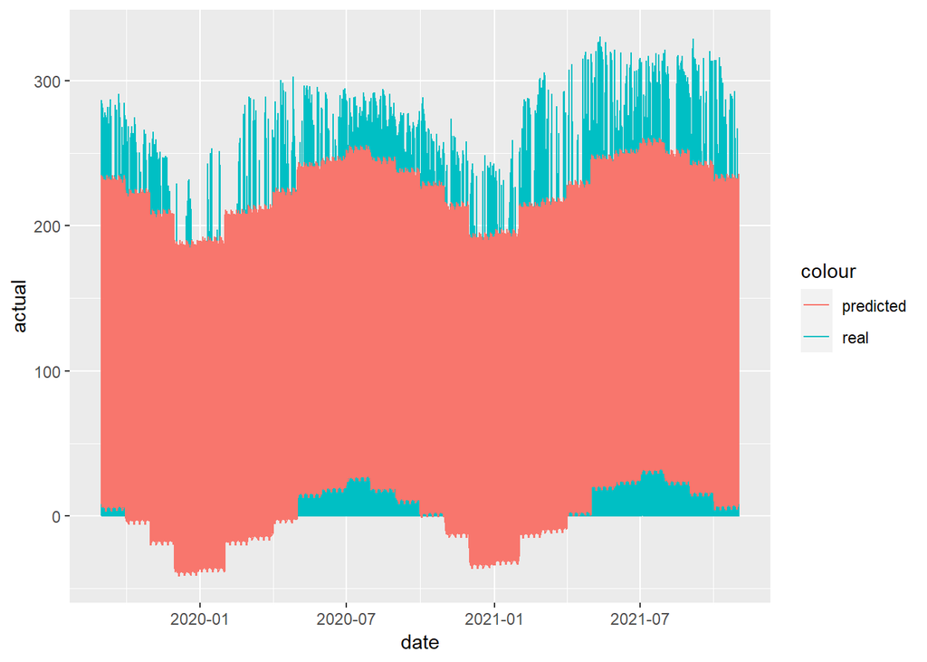

```r
tmp=copy(data)
tmp[,actual:=production]
tmp[,predicted:=predict(lm_base,tmp)]
tmp[,residual:= actual-predicted]
#head(tmp)
ggplot(tmp ,aes(x=date)) +
        geom_line(aes(y=actual,color='real')) +
        geom_line(aes(y=predicted,color='predicted'))
```

By observing the graph, it can be said that there is fluctions in data and the production can not be negative but production can not be negative, therefore it is recorded as 0.

```r
#checkresiduals(lm_base)
```

### Learning from Residuals by Rpart tree method.

We know use temperature values as regressors. They are predicted before the time t, so we can use as regresors at time t. the production values is unkown for time t. however we know the t-1 values so, it can be used as lag values as regressors, I added the lag values as regressors too.

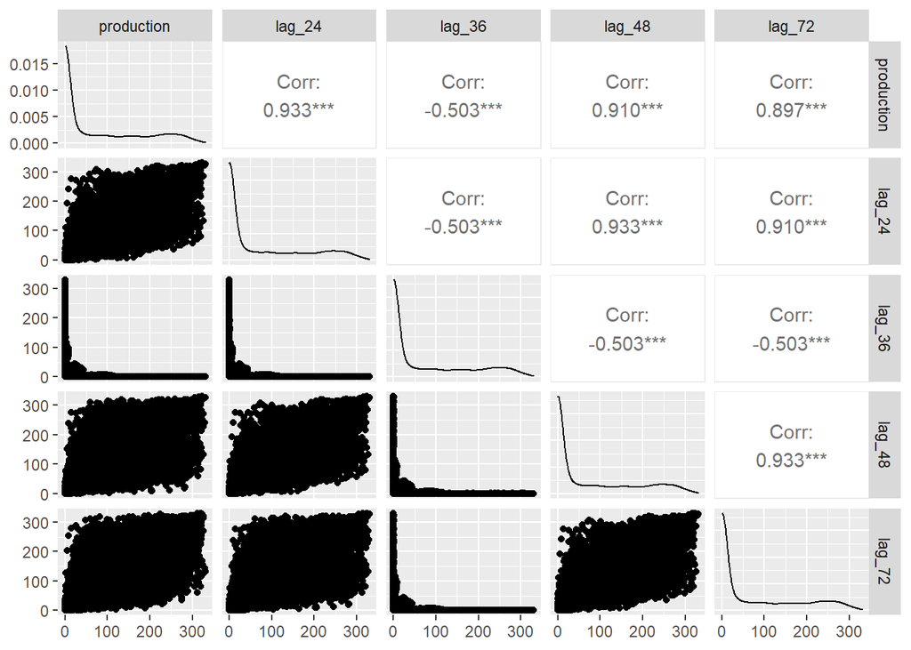

```r
library(GGally)
lag_data = data[,"production"]

for( i in c(24,36,48,72) ){
 lag_data[, sprintf("lag_%s",i) := shift(production,i)]

}
ggpairs(lag_data)
```

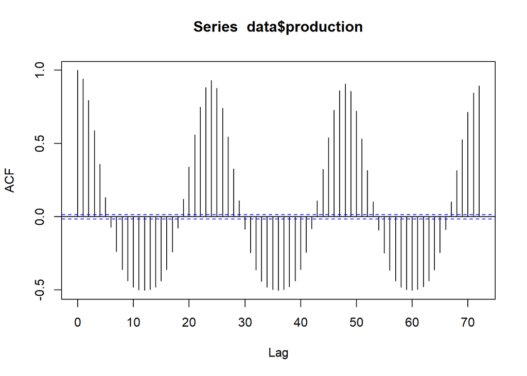

```r
acf(data$production, 72)
```

I visualize the 24,26,48, and 72 values of correlation with production rate and they are very significant. I added them as regeressors.

```r
for( i in c(24,36,48,72)  ){
 tmp[, sprintf("lag_%s",i) := shift(production,i)]

}
```

Now, I create rpart model for residuals too see other regressors effects on residuals and then I will add a variable as regresor to my base model which explains bigger absoulute value of residuals in the base line model.

```r
head(tmp)
```

```
##          date hour production DSWRF_surface_38_35 DSWRF_surface_38_35.25 DSWRF_surface_38_35.5
## 1: 2019-09-01    0     0.0000                   0                      0                     0
## 2: 2019-09-01    1     0.0000                   0                      0                     0
## 3: 2019-09-01    2     0.0000                   0                      0                     0
## 4: 2019-09-01    3     0.0000                   0                      0                     0
## 5: 2019-09-01    4     0.0000                   0                      0                     0
##    DSWRF_surface_38_35.75 DSWRF_surface_38_36 DSWRF_surface_38.25_35 DSWRF_surface_38.25_35.25
## 1:                      0                   0                      0                         0
## 2:                      0                   0                      0                         0
## 3:                      0                   0                      0                         0
## 4:                      0                   0                      0                         0
## 5:                      0                   0                      0                         0
##    DSWRF_surface_38.25_35.5 DSWRF_surface_38.25_35.75 DSWRF_surface_38.25_36 DSWRF_surface_38.5_35
## 1:                        0                         0                      0                     0
## 2:                        0                         0                      0                     0
```

[output cut: 352 more lines]

[figure not shown]

```r
library(rattle)

tmp = tmp[73:nrow(tmp)]

fit_res_tree=rpart(residual~ .-production-actual-date-predicted,tmp,
                   control=rpart.control(cp=0,maxdepth=4))
fancyRpartPlot(fit_res_tree)
```

```r
summary(fit_res_tree)
```

```
## Call:
## rpart(formula = residual ~ . - production - actual - date - predicted,
##     data = tmp, control = rpart.control(cp = 0, maxdepth = 4))
##   n= 18912
##
##             CP nsplit rel error    xerror       xstd
## 1  0.113134083      0 1.0000000 1.0001364 0.01570114
## 2  0.101397848      1 0.8868659 0.8904024 0.01522957
## 3  0.059476714      3 0.6840702 0.7013895 0.01126452
## 4  0.030869345      4 0.6245935 0.6421102 0.01166784
## 5  0.030143027      5 0.5937242 0.6138380 0.01105717
## 6  0.026451309      6 0.5635811 0.5944209 0.01089545
## 7  0.024112091      7 0.5371298 0.5638130 0.01115719
## 8  0.019040499      8 0.5130177 0.5430550 0.01097125
## 9  0.007770573      9 0.4939772 0.5249559 0.01049135
## 10 0.007404962     10 0.4862067 0.5217172 0.01045657
## 11 0.005770434     11 0.4788017 0.5194552 0.01042178
## 12 0.003219133     12 0.4730313 0.5076322 0.01025575
## 13 0.002105491     13 0.4698121 0.5077825 0.01028240
## 14 0.001951942     14 0.4677066 0.5061111 0.01025932
## 15 0.000000000     15 0.4657547 0.5065923 0.01028698
##
## Variable importance
##     TCDC_entire.atmosphere_38.75_35  TCDC_entire.atmosphere_38.75_35.25
##                                   6                                   5
##        TCDC_entire.atmosphere_39_35     TCDC_entire.atmosphere_39_35.25
##                                   5                                   5
##      TCDC_entire.atmosphere_38.5_35      TCDC_entire.atmosphere_39_35.5
##                                   5                                   5
##              DSWRF_surface_39_35.25                 DSWRF_surface_39_35
##                                   5                                   4
##               DSWRF_surface_39_35.5           DSWRF_surface_38.75_35.25
##                                   4                                   4
##              DSWRF_surface_38.75_35               DSWRF_surface_38.5_35
##                                   4                                   4
##                              lag_24                              lag_72
##                                   4                                   3
##                              lag_48                              lag_36
##                                   3                                   3
##                                 mon       TMP_2.m.above.ground_38_35.75
```

[output cut: 292 more lines]

```
##
## Node number 27: 326 observations
##   mean=14.24471, MSE=1135.436
##
## Node number 28: 15 observations
##   mean=-56.79803, MSE=2545.894
##
## Node number 29: 160 observations
##   mean=11.22731, MSE=925.043
##
## Node number 30: 1218 observations
##   mean=35.65303, MSE=613.8983
##
## Node number 31: 906 observations
##   mean=53.9498, MSE=603.3974
```

In node 16, the absolute value is bigger than others therefore, the path of this node is used as regressors.

```r
tmp[,is_DSWRF_surface_39_35.25 := DSWRF_surface_39_35.25 <589.358]
tmp[,is_lag_36:= lag_36 < 0.000950]
tmp[,is_TCDC_TCDC_entire.atmosphere_38.75_35:= TCDC_entire.atmosphere_38.75_35 >= 63]
tmp[,is_TCDC_low.cloud.layer_38_35.75:= TCDC_low.cloud.layer_38_35.75 >= 0.1]
```

## Model 2

```r
lm_base_2=lm(production~trnd+w_day+mon+as.factor(hour)+ is_DSWRF_surface_39_35.25:is_TCDC_TCDC_entire.atmosphere_38.75_35:is_lag_36:is_TCDC_low.cloud.layer_38_35.75,tmp)

summary(lm_base_2)
```

```
##
## Call:
## lm(formula = production ~ trnd + w_day + mon + as.factor(hour) +
##     is_DSWRF_surface_39_35.25:is_TCDC_TCDC_entire.atmosphere_38.75_35:is_lag_36:is_TCDC_low.cloud.layer_38_35.75,
##     data = tmp)
##
## Residuals:
##      Min       1Q   Median       3Q      Max
## -199.309   -9.801   -1.379   14.590  151.359
##
## Coefficients: (1 not defined because of singularities)
##                                                                                                                                    Estimate
## (Intercept)                                                                                                                      -7.645e+01
## trnd                                                                                                                              5.161e-04
## w_dayMon                                                                                                                          1.306e+00
## w_daySat                                                                                                                          4.064e-01
## w_daySun                                                                                                                          3.310e+00
## w_dayThu                                                                                                                          1.061e+00
## w_dayTue                                                                                                                          2.366e+00
## w_dayWed                                                                                                                          4.532e-01
## monAug                                                                                                                            5.143e-01
## monDec                                                                                                                           -2.371e+01
## monFeb                                                                                                                           -5.888e+00
## monJan                                                                                                                           -1.956e+01
## monJul                                                                                                                            2.726e+00
## monJun                                                                                                                            5.658e+00
## monMar                                                                                                                           -2.958e+00
## monMay                                                                                                                            4.534e+00
## monNov                                                                                                                           -1.173e+01
## monOct                                                                                                                           -3.768e+00
## monSep                                                                                                                           -2.833e+00
## as.factor(hour)1                                                                                                                  2.531e-02
## as.factor(hour)2                                                                                                                  2.641e-02
## as.factor(hour)3                                                                                                                  4.426e-02
## as.factor(hour)4                                                                                                                 -1.964e-01
## as.factor(hour)5                                                                                                                  4.786e-01
## as.factor(hour)6                                                                                                                  1.051e+01
## as.factor(hour)7                                                                                                                  4.788e+01
## as.factor(hour)8                                                                                                                  1.082e+02
## as.factor(hour)9                                                                                                                  1.665e+02
```

[output cut: 258 more lines]

```
## is_DSWRF_surface_39_35.25FALSE:is_TCDC_TCDC_entire.atmosphere_38.75_35FALSE:is_lag_36FALSE:is_TCDC_low.cloud.layer_38_35.75TRUE  ***
## is_DSWRF_surface_39_35.25TRUE:is_TCDC_TCDC_entire.atmosphere_38.75_35FALSE:is_lag_36FALSE:is_TCDC_low.cloud.layer_38_35.75TRUE   ***
## is_DSWRF_surface_39_35.25FALSE:is_TCDC_TCDC_entire.atmosphere_38.75_35TRUE:is_lag_36FALSE:is_TCDC_low.cloud.layer_38_35.75TRUE   ***
## is_DSWRF_surface_39_35.25TRUE:is_TCDC_TCDC_entire.atmosphere_38.75_35TRUE:is_lag_36FALSE:is_TCDC_low.cloud.layer_38_35.75TRUE    ***
## is_DSWRF_surface_39_35.25FALSE:is_TCDC_TCDC_entire.atmosphere_38.75_35FALSE:is_lag_36TRUE:is_TCDC_low.cloud.layer_38_35.75TRUE   ***
## is_DSWRF_surface_39_35.25TRUE:is_TCDC_TCDC_entire.atmosphere_38.75_35FALSE:is_lag_36TRUE:is_TCDC_low.cloud.layer_38_35.75TRUE    ***
## is_DSWRF_surface_39_35.25FALSE:is_TCDC_TCDC_entire.atmosphere_38.75_35TRUE:is_lag_36TRUE:is_TCDC_low.cloud.layer_38_35.75TRUE    ***
## is_DSWRF_surface_39_35.25TRUE:is_TCDC_TCDC_entire.atmosphere_38.75_35TRUE:is_lag_36TRUE:is_TCDC_low.cloud.layer_38_35.75TRUE
## ---
## Signif. codes:  0 '***' 0.001 '**' 0.01 '*' 0.05 '.' 0.1 ' ' 1
##
## Residual standard error: 29.35 on 18854 degrees of freedom
##   (1 observation deleted due to missingness)
## Multiple R-squared:  0.9087, Adjusted R-squared:  0.9084
## F-statistic:  3350 on 56 and 18854 DF,  p-value: < 2.2e-16
```

## Rpart Model 2

[figure not shown]

```r
tmp_v2 = copy(tmp)

tmp_v2$predicted =predict(lm_base_2,tmp_v2)
tmp_v2$residual= tmp_v2$actual-tmp_v2$predicted

fit_res_tree_2=rpart(residual~ .-production-actual-date-predicted -is_DSWRF_surface_39_35.25-is_TCDC_TCDC_entire.atmosphere_38.75_35-is_lag_36- is_TCDC_low.cloud.layer_38_35.75
                   ,tmp_v2,
                   control=rpart.control(cp=0,maxdepth=4))
fancyRpartPlot(fit_res_tree_2)
```

Now, we use the node 24 path which give the result -69

```r
tmp_v2[,is_lag24 := lag_24 <146]
tmp_v2[,is_TCDC_middle.cloud.layer_38.75_35.75 := TCDC_middle.cloud.layer_38.75_35.75 < 5.7 ]
tmp_v2[,is_TCDC_low.cloud.layer_38.5_35.25 := TCDC_low.cloud.layer_38.5_35.25 < 93 ]
tmp_v2[,is_DSWRF_surface_38.75_35.25 := DSWRF_surface_38.75_35.25 < 435 ]
```

## lm base 3

```r
lm_base_3=lm(production~trnd+w_day+mon+as.factor(hour)+ is_DSWRF_surface_39_35.25:is_TCDC_TCDC_entire.atmosphere_38.75_35:is_lag_36:is_TCDC_low.cloud.layer_38_35.75 +is_lag24:is_TCDC_middle.cloud.layer_38.75_35.75:is_TCDC_low.cloud.layer_38.5_35.25:is_DSWRF_surface_38.75_35.25
               ,tmp_v2)
summary(lm_base_3)
```

```
##
## Call:
## lm(formula = production ~ trnd + w_day + mon + as.factor(hour) +
##     is_DSWRF_surface_39_35.25:is_TCDC_TCDC_entire.atmosphere_38.75_35:is_lag_36:is_TCDC_low.cloud.layer_38_35.75 +
##     is_lag24:is_TCDC_middle.cloud.layer_38.75_35.75:is_TCDC_low.cloud.layer_38.5_35.25:is_DSWRF_surface_38.75_35.25,
##     data = tmp_v2)
##
## Residuals:
##      Min       1Q   Median       3Q      Max
## -215.896   -7.786   -0.703    9.998  137.536
##
## Coefficients: (2 not defined because of singularities)
##                                                                                                                                       Estimate
## (Intercept)                                                                                                                         -5.132e+01
## trnd                                                                                                                                 4.807e-04
## w_dayMon                                                                                                                            -2.107e-01
## w_daySat                                                                                                                             5.803e-01
## w_daySun                                                                                                                             2.760e+00
## w_dayThu                                                                                                                             6.294e-01
## w_dayTue                                                                                                                             2.134e+00
## w_dayWed                                                                                                                            -3.423e-01
## monAug                                                                                                                              -4.148e+00
## monDec                                                                                                                              -1.725e+01
## monFeb                                                                                                                              -5.862e+00
## monJan                                                                                                                              -1.467e+01
## monJul                                                                                                                              -2.212e+00
## monJun                                                                                                                               1.731e+00
## monMar                                                                                                                              -2.767e+00
## monMay                                                                                                                               2.087e+00
## monNov                                                                                                                              -1.102e+01
## monOct                                                                                                                              -6.285e+00
## monSep                                                                                                                              -4.473e+00
## as.factor(hour)1                                                                                                                    -3.666e-03
## as.factor(hour)2                                                                                                                     4.627e-02
## as.factor(hour)3                                                                                                                     7.857e-02
## as.factor(hour)4                                                                                                                    -3.506e-01
## as.factor(hour)5                                                                                                                     3.215e-01
## as.factor(hour)6                                                                                                                     9.793e+00
## as.factor(hour)7                                                                                                                     4.590e+01
## as.factor(hour)8                                                                                                                     9.036e+01
```

[output cut: 339 more lines]

```
## is_lag24FALSE:is_TCDC_middle.cloud.layer_38.75_35.75FALSE:is_TCDC_low.cloud.layer_38.5_35.25FALSE:is_DSWRF_surface_38.75_35.25TRUE  ***
## is_lag24TRUE:is_TCDC_middle.cloud.layer_38.75_35.75FALSE:is_TCDC_low.cloud.layer_38.5_35.25FALSE:is_DSWRF_surface_38.75_35.25TRUE   ***
## is_lag24FALSE:is_TCDC_middle.cloud.layer_38.75_35.75TRUE:is_TCDC_low.cloud.layer_38.5_35.25FALSE:is_DSWRF_surface_38.75_35.25TRUE   ***
## is_lag24TRUE:is_TCDC_middle.cloud.layer_38.75_35.75TRUE:is_TCDC_low.cloud.layer_38.5_35.25FALSE:is_DSWRF_surface_38.75_35.25TRUE
## is_lag24FALSE:is_TCDC_middle.cloud.layer_38.75_35.75FALSE:is_TCDC_low.cloud.layer_38.5_35.25TRUE:is_DSWRF_surface_38.75_35.25TRUE   ***
## is_lag24TRUE:is_TCDC_middle.cloud.layer_38.75_35.75FALSE:is_TCDC_low.cloud.layer_38.5_35.25TRUE:is_DSWRF_surface_38.75_35.25TRUE    ***
## is_lag24FALSE:is_TCDC_middle.cloud.layer_38.75_35.75TRUE:is_TCDC_low.cloud.layer_38.5_35.25TRUE:is_DSWRF_surface_38.75_35.25TRUE    ***
## is_lag24TRUE:is_TCDC_middle.cloud.layer_38.75_35.75TRUE:is_TCDC_low.cloud.layer_38.5_35.25TRUE:is_DSWRF_surface_38.75_35.25TRUE
## ---
## Signif. codes:  0 '***' 0.001 '**' 0.01 '*' 0.05 '.' 0.1 ' ' 1
##
## Residual standard error: 25.54 on 18839 degrees of freedom
##   (1 observation deleted due to missingness)
## Multiple R-squared:  0.9309, Adjusted R-squared:  0.9307
## F-statistic:  3576 on 71 and 18839 DF,  p-value: < 2.2e-16
```

## rpart model 3

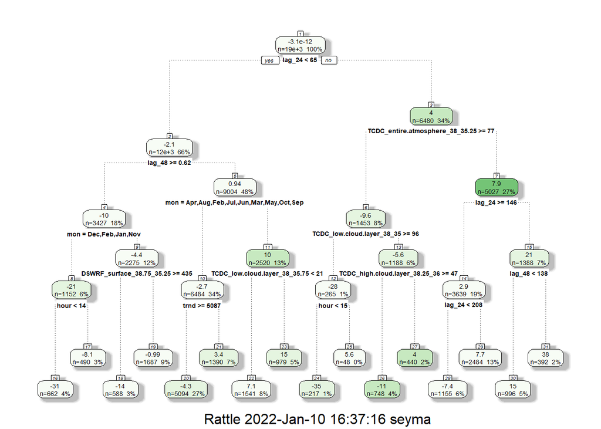

```r
tmp_v3 = copy(tmp_v2)

tmp_v3$predicted =predict(lm_base_3,tmp_v3)
tmp_v3$residual= tmp_v3$actual-tmp_v3$predicted

fit_res_tree_3=rpart(residual~ .-production-actual-date-predicted -is_DSWRF_surface_39_35.25-is_TCDC_TCDC_entire.atmosphere_38.75_35-is_lag_36- is_TCDC_low.cloud.layer_38_35.75 - is_lag24-is_TCDC_middle.cloud.layer_38.75_35.75-is_TCDC_low.cloud.layer_38.5_35.25-is_DSWRF_surface_38.75_35.25
                   ,tmp_v3,
                   control=rpart.control(cp=0,maxdepth=4))
fancyRpartPlot(fit_res_tree_3)
```

```r
#summary(fit_res_tree_3)
tmp_v3[, is_lag_24_2 := lag_24 >  65.37035]
tmp_v3[, is_TCDC_entire.atmosphere_38_35.25 := TCDC_entire.atmosphere_38_35.25 >= 76.9]
tmp_v3[, is_lag_24_3 := lag_24 <146]
tmp_v3[, is_lag_48_2 :=lag_48 >= 138]
```

```r
lm_base_4=lm(production~trnd+w_day+mon+as.factor(hour)+ is_DSWRF_surface_39_35.25:is_TCDC_TCDC_entire.atmosphere_38.75_35:is_lag_36:is_TCDC_low.cloud.layer_38_35.75 +is_lag24:is_TCDC_middle.cloud.layer_38.75_35.75:is_TCDC_low.cloud.layer_38.5_35.25:is_DSWRF_surface_38.75_35.25 + is_lag_24_2:is_TCDC_entire.atmosphere_38_35.25:is_lag_24_3:is_lag_48_2
               ,tmp_v3)
summary(lm_base_4)
```

```
##
## Call:
## lm(formula = production ~ trnd + w_day + mon + as.factor(hour) +
##     is_DSWRF_surface_39_35.25:is_TCDC_TCDC_entire.atmosphere_38.75_35:is_lag_36:is_TCDC_low.cloud.layer_38_35.75 +
##     is_lag24:is_TCDC_middle.cloud.layer_38.75_35.75:is_TCDC_low.cloud.layer_38.5_35.25:is_DSWRF_surface_38.75_35.25 +
##     is_lag_24_2:is_TCDC_entire.atmosphere_38_35.25:is_lag_24_3:is_lag_48_2,
##     data = tmp_v3)
##
## Residuals:
##      Min       1Q   Median       3Q      Max
## -215.661   -6.695   -0.474    8.211  142.575
##
## Coefficients: (8 not defined because of singularities)
##                                                                                                                                       Estimate
## (Intercept)                                                                                                                         -2.300e+01
## trnd                                                                                                                                 4.168e-04
## w_dayMon                                                                                                                            -5.253e-01
## w_daySat                                                                                                                             4.299e-01
## w_daySun                                                                                                                             2.498e+00
## w_dayThu                                                                                                                             6.160e-01
## w_dayTue                                                                                                                             1.556e+00
## w_dayWed                                                                                                                            -4.860e-01
## monAug                                                                                                                              -6.836e+00
## monDec                                                                                                                              -1.586e+01
## monFeb                                                                                                                              -5.341e+00
## monJan                                                                                                                              -1.339e+01
## monJul                                                                                                                              -4.939e+00
## monJun                                                                                                                              -1.492e+00
## monMar                                                                                                                              -2.551e+00
## monMay                                                                                                                               1.740e-01
## monNov                                                                                                                              -1.063e+01
## monOct                                                                                                                              -7.788e+00
## monSep                                                                                                                              -6.225e+00
## as.factor(hour)1                                                                                                                     7.638e-02
## as.factor(hour)2                                                                                                                     1.272e-01
## as.factor(hour)3                                                                                                                     1.869e-01
## as.factor(hour)4                                                                                                                    -4.204e-01
## as.factor(hour)5                                                                                                                     2.656e-01
## as.factor(hour)6                                                                                                                     9.056e+00
## as.factor(hour)7                                                                                                                     3.273e+01
```

[output cut: 420 more lines]

```
## is_lag_24_2FALSE:is_TCDC_entire.atmosphere_38_35.25FALSE:is_lag_24_3FALSE:is_lag_48_2TRUE
## is_lag_24_2TRUE:is_TCDC_entire.atmosphere_38_35.25FALSE:is_lag_24_3FALSE:is_lag_48_2TRUE                                            ***
## is_lag_24_2FALSE:is_TCDC_entire.atmosphere_38_35.25TRUE:is_lag_24_3FALSE:is_lag_48_2TRUE
## is_lag_24_2TRUE:is_TCDC_entire.atmosphere_38_35.25TRUE:is_lag_24_3FALSE:is_lag_48_2TRUE
## is_lag_24_2FALSE:is_TCDC_entire.atmosphere_38_35.25FALSE:is_lag_24_3TRUE:is_lag_48_2TRUE                                            ***
## is_lag_24_2TRUE:is_TCDC_entire.atmosphere_38_35.25FALSE:is_lag_24_3TRUE:is_lag_48_2TRUE                                             ***
## is_lag_24_2FALSE:is_TCDC_entire.atmosphere_38_35.25TRUE:is_lag_24_3TRUE:is_lag_48_2TRUE                                             ***
## is_lag_24_2TRUE:is_TCDC_entire.atmosphere_38_35.25TRUE:is_lag_24_3TRUE:is_lag_48_2TRUE
## ---
## Signif. codes:  0 '***' 0.001 '**' 0.01 '*' 0.05 '.' 0.1 ' ' 1
##
## Residual standard error: 23.29 on 18829 degrees of freedom
##   (1 observation deleted due to missingness)
## Multiple R-squared:  0.9426, Adjusted R-squared:  0.9423
## F-statistic:  3816 on 81 and 18829 DF,  p-value: < 2.2e-16
```

The adjusted R-squared is increased around %1 so the iterations stops in here.

```r
#checkresiduals(lm_base_4)
```

# predictions

The model 4 is used for predictions and compared with simplest baseline of using last available data (lag 48 production → two day’s ago).

```r
raw_data = fread("production_with_weather_data.csv")
raw_data[,w_day:=as.character(wday(date,label=T))]
raw_data[,mon:=as.character(month(date,label=T))]
raw_data[,trnd:= 1:.N]
for( i in c(24,36,48,72)  ){
 raw_data[, sprintf("lag_%s",i) := shift(production,i)]

}




raw_data[,is_DSWRF_surface_39_35.25 := DSWRF_surface_39_35.25 <589.358]
raw_data[,is_lag_36:= lag_36 < 0.000950]
raw_data[,is_TCDC_TCDC_entire.atmosphere_38.75_35:= TCDC_entire.atmosphere_38.75_35 >= 63]
raw_data[,is_TCDC_low.cloud.layer_38_35.75:= TCDC_low.cloud.layer_38_35.75 >= 0.1]
raw_data[,is_lag24 := lag_24 <146]
raw_data[,is_TCDC_middle.cloud.layer_38.75_35.75 := TCDC_middle.cloud.layer_38.75_35.75 < 5.7 ]
raw_data[,is_TCDC_low.cloud.layer_38.5_35.25 := TCDC_low.cloud.layer_38.5_35.25 < 93 ]
raw_data[,is_DSWRF_surface_38.75_35.25 := DSWRF_surface_38.75_35.25 < 435 ]
raw_data[, is_lag_24_2 := lag_24 >  65.37035]
raw_data[, is_TCDC_entire.atmosphere_38_35.25 := TCDC_entire.atmosphere_38_35.25 >= 76.9]
raw_data[, is_lag_24_3 := lag_24 <146]
raw_data[, is_lag_48_2 :=lag_48 >= 138]
raw_data[is.na(is_TCDC_low.cloud.layer_38.5_35.25)]$is_TCDC_low.cloud.layer_38.5_35.25 = TRUE
raw_data[is.na(is_DSWRF_surface_38.75_35.25)]$is_DSWRF_surface_38.75_35.25 = TRUE
raw_data[is.na(is_TCDC_low.cloud.layer_38_35.75)]$is_TCDC_low.cloud.layer_38_35.75 = TRUE
raw_data[is.na(is_DSWRF_surface_39_35.25)]$is_DSWRF_surface_39_35.25 = TRUE

test_data = raw_data[date>=  "2021-11-01"  ]
head(test_data)
```

```
##          date hour production DSWRF_surface_38_35 DSWRF_surface_38_35.25 DSWRF_surface_38_35.5
## 1: 2021-11-01    0     0.0000                   0                      0                     0
## 2: 2021-11-01    1     0.0000                   0                      0                     0
## 3: 2021-11-01    2     0.0002                   0                      0                     0
## 4: 2021-11-01    3     0.0001                   0                      0                     0
## 5: 2021-11-01    4     0.0157                   0                      0                     0
##    DSWRF_surface_38_35.75 DSWRF_surface_38_36 DSWRF_surface_38.25_35 DSWRF_surface_38.25_35.25
## 1:                      0                   0                      0                         0
## 2:                      0                   0                      0                         0
## 3:                      0                   0                      0                         0
## 4:                      0                   0                      0                         0
## 5:                      0                   0                      0                         0
##    DSWRF_surface_38.25_35.5 DSWRF_surface_38.25_35.75 DSWRF_surface_38.25_36 DSWRF_surface_38.5_35
## 1:                        0                         0                      0                     0
## 2:                        0                         0                      0                     0
```

[output cut: 370 more lines]

```r
summary(test_data)
```

```
##       date                 hour         production        DSWRF_surface_38_35 DSWRF_surface_38_35.25
##  Min.   :2021-11-01   Min.   : 0.00   Min.   :  0.00000   Min.   :  0.00      Min.   :  0.00
##  1st Qu.:2021-11-14   1st Qu.: 5.75   1st Qu.:  0.00170   1st Qu.:  0.00      1st Qu.:  0.00
##  Median :2021-11-27   Median :11.50   Median :  0.01725   Median : 23.72      Median : 23.71
##  Mean   :2021-11-27   Mean   :11.50   Mean   : 45.46808   Mean   :114.25      Mean   :114.28
##  3rd Qu.:2021-12-11   3rd Qu.:17.25   3rd Qu.: 53.32580   3rd Qu.:202.48      3rd Qu.:203.34
##  DSWRF_surface_38_35.5 DSWRF_surface_38_35.75 DSWRF_surface_38_36 DSWRF_surface_38.25_35
##  Min.   :  0.00        Min.   :  0.00         Min.   :  0.00      Min.   :  0.00
##  1st Qu.:  0.00        1st Qu.:  0.00         1st Qu.:  0.00      1st Qu.:  0.00
##  Median : 18.54        Median : 15.02         Median : 13.94      Median : 22.46
##  Mean   :104.44        Mean   :100.06         Mean   : 99.74      Mean   :107.89
##  3rd Qu.:163.52        3rd Qu.:148.92         3rd Qu.:141.18      3rd Qu.:184.34
##  DSWRF_surface_38.25_35.25 DSWRF_surface_38.25_35.5 DSWRF_surface_38.25_35.75 DSWRF_surface_38.25_36
##  Min.   :  0.0             Min.   :  0.00           Min.   :  0.00            Min.   :  0.00
##  1st Qu.:  0.0             1st Qu.:  0.00           1st Qu.:  0.00            1st Qu.:  0.00
##  Median : 25.4             Median : 22.08           Median : 22.72            Median : 19.48
##  Mean   :106.5             Mean   :106.26           Mean   :106.82            Mean   :104.04
##  3rd Qu.:186.3             3rd Qu.:182.84           3rd Qu.:177.30            3rd Qu.:164.46
##  DSWRF_surface_38.5_35 DSWRF_surface_38.5_35.25 DSWRF_surface_38.5_35.5 DSWRF_surface_38.5_35.75
##  Min.   :  0.00        Min.   :  0.00           Min.   :  0.00          Min.   :  0.00
##  1st Qu.:  0.00        1st Qu.:  0.00           1st Qu.:  0.00          1st Qu.:  0.00
##  Median : 23.38        Median : 25.14           Median : 22.29          Median : 21.28
##  Mean   :106.72        Mean   :107.83           Mean   :106.24          Mean   :105.26
##  3rd Qu.:183.20        3rd Qu.:186.76           3rd Qu.:174.92          3rd Qu.:176.28
##  DSWRF_surface_38.5_36 DSWRF_surface_38.75_35 DSWRF_surface_38.75_35.25 DSWRF_surface_38.75_35.5
##  Min.   :  0.00        Min.   :  0.00         Min.   :  0.00            Min.   :  0.00
##  1st Qu.:  0.00        1st Qu.:  0.00         1st Qu.:  0.00            1st Qu.:  0.00
##  Median : 23.04        Median : 21.56         Median : 23.76            Median : 20.42
##  Mean   :106.04        Mean   :103.66         Mean   :102.72            Mean   :102.24
##  3rd Qu.:177.06        3rd Qu.:169.80         3rd Qu.:169.20            3rd Qu.:170.58
##  DSWRF_surface_38.75_35.75 DSWRF_surface_38.75_36 DSWRF_surface_39_35 DSWRF_surface_39_35.25
##  Min.   :  0.0             Min.   :  0.00         Min.   :  0.00      Min.   :  0.00
##  1st Qu.:  0.0             1st Qu.:  0.00         1st Qu.:  0.00      1st Qu.:  0.00
##  Median : 21.6             Median : 23.14         Median : 21.92      Median : 22.54
##  Mean   :104.8             Mean   :104.96         Mean   :104.96      Mean   :103.01
##  3rd Qu.:173.8             3rd Qu.:168.96         3rd Qu.:179.00      3rd Qu.:170.80
##  DSWRF_surface_39_35.5 DSWRF_surface_39_35.75 DSWRF_surface_39_36 RH_2.m.above.ground_38_35
##  Min.   :  0.00        Min.   :  0.00         Min.   :  0.00      Min.   : 18.50
##  1st Qu.:  0.00        1st Qu.:  0.00         1st Qu.:  0.00      1st Qu.: 45.52
##  Median : 20.16        Median : 21.52         Median : 21.54      Median : 60.30
```

[output cut: 330 more lines]

```
##
##
##  is_DSWRF_surface_38.75_35.25 is_lag_24_2     is_TCDC_entire.atmosphere_38_35.25 is_lag_24_3
##  Mode :logical                Mode :logical   Mode :logical                      Mode :logical
##  FALSE:43                     FALSE:999       FALSE:745                          FALSE:177
##  TRUE :1253                   TRUE :297       TRUE :551                          TRUE :1119
##
##
##  is_lag_48_2
##  Mode :logical
##  FALSE:1104
##  TRUE :192
##
##
##  [ reached getOption("max.print") -- omitted 2 rows ]
```

```r
model_predictions = as.numeric(predict(lm_base_4,test_data))
model_predictions[model_predictions<0] = 0
actual = test_data$production

residuals = as.numeric(abs(actual -model_predictions))
model_wampe = sum(residuals)/sum(actual)
base_line_predictions = test_data$lag_48
base_line_wampe = sum(abs(base_line_predictions- actual)) / sum(actual)

print("model based wampe")
```

```
## [1] "model based wampe"
```

```r
print(model_wampe)
```

```
## [1] 0.3496064
```

```r
print("base line  wampe")
```

```
## [1] "base line  wampe"
```

```r
print(base_line_wampe)
```

```
## [1] 0.5045976
```

## Discussion

As seen above the modelbased approach has much smaller wampe value which is desired. However, model estimates sometimes the production lower than zero whixh is not possible therefore they changed as 0.